# EDA wine prices

| V1 | country | description | designation | points | price | province | region_1 | region_2 | variety | winery |
| --- | --- | --- | --- | --- | --- | --- | --- | --- | --- | --- |
| 0 | US | This tremendous 100% varietal wine hails from Oakville and was aged over three years in oak. Juicy red-cherry fruit and a compelling hint of caramel greet the palate, framed by elegant, fine tannins a… | Martha's Vineyard | 96 | 235 | California | Napa Valley | Napa | Cabernet Sauvignon | Heitz |
| 1 | Spain | Ripe aromas of fig, blackberry and cassis are softened and sweetened by a slathering of oaky chocolate and vanilla. This is full, layered, intense and cushioned on the palate, with rich flavors of cho… | Carodorum Selección Especial Reserva | 96 | 110 | Northern Spain | Toro |  | Tinta de Toro | Bodega Carmen Rodríguez |
| 2 | US | Mac Watson honors the memory of a wine once made by his mother in this tremendously delicious, balanced and complex botrytised white. Dark gold in color, it layers toasted hazelnut, pear compote and o… | Special Selected Late Harvest | 96 | 90 | California | Knights Valley | Sonoma | Sauvignon Blanc | Macauley |
| 3 | US | This spent 20 months in 30% new French oak, and incorporates fruit from Ponzi's Aurora, Abetina and Madrona vineyards, among others. Aromatic, dense and toasty, it deftly blends aromas and flavors of … | Reserve | 96 | 65 | Oregon | Willamette Valley | Willamette Valley | Pinot Noir | Ponzi |
| 4 | France | This is the top wine from La Bégude, named after the highest point in the vineyard at 1200 feet. It has structure, density and considerable acidity that is still calming down. With 18 months in wood, … | La Brûlade | 95 | 66 | Provence | Bandol |  | Provence red blend | Domaine de la Bégude |
| 5 | Spain | Deep, dense and pure from the opening bell, this Toro is a winner. Aromas of dark ripe black fruits are cool and moderately oaked. This feels massive on the palate but sensationally balanced. Flavors … | Numanthia | 95 | 73 | Northern Spain | Toro |  | Tinta de Toro | Numanthia |

## Data cleaning

First, we want to drop any columns we’re not interested in. In this analysis, we will focus only on: - points - price - country - province - variety

We’re omitting any other variables since we don’t need them to answer this question.

We also need to drop any data where we don’t have prices and impute any missing data (or drop it).

```r
summary(dt)
```

```
     points           price           province           country            variety
 Min.   : 80.00   Min.   :   4.00   Length:137235      Length:137235      Length:137235
 1st Qu.: 86.00   1st Qu.:  16.00   Class :character   Class :character   Class :character
 Median : 88.00   Median :  24.00   Mode  :character   Mode  :character   Mode  :character
 Mean   : 87.79   Mean   :  33.13
 3rd Qu.: 90.00   3rd Qu.:  40.00
 Max.   :100.00   Max.   :2300.00
```

## EDA

Second, we will look into the dataset. How many observations? How many different regions? Is there enough between regions and varietals of wine? What about the relationship between `points` and `price`?

Overall, we’re trying to find out *what are some good predictors* for the price of each wine bottle.

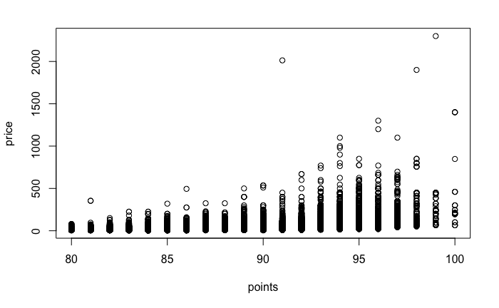

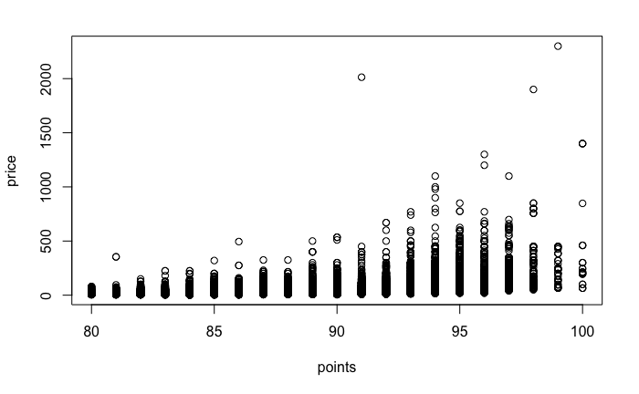

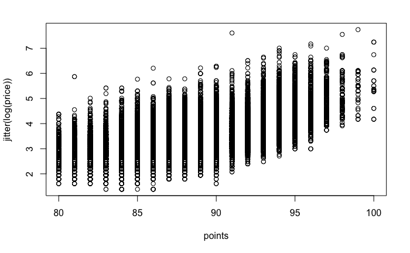

```r
plot(price ~ points, data = dt)
plot(price ~ points, data = dt)

plot(jitter(log(price)) ~ points, data = dt) # the relationship looks more linear if we plot the logs
```

We see from the above that there is a positive relationship between points and price for a bottle of wine. However, for higher points, we are seeing a larger variation of prices, and interestingly, for wines with 100 points, we have much fewer data points, and also the prices we see are somewhat lower than for lower prices.

What about the relationship between `price` and the region on the varietal?

[output not shown]

[output cut: 990 more lines]